# Лабораторная работа №7

ДИОН ГОНССАН СЕДРИК МИШЕЛ

RUDN University, Moscow, Russian Federation

## Цель работы

Освоение основных возможностей командной оболочки Midnight Commander. Приобретение навыков практической работы по просмотру каталогов и файлов; манипуляций с ними.

## Задание

Задание по mc: 1. Изучите информацию о mc, вызвав в командной строке man mc. 2. Запустите из командной строки mc, изучите его структуру и меню. 3. Выполните несколько операций в mc, используя управляющие клавиши (операции с панелями; выделение/отмена выделения файлов, копирование/перемещение файлов, получение информации о размере и правах доступа на файлы и/или каталоги и т.п.) 4. Выполните основные команды меню левой (или правой) панели. Оцените степень подробности вывода информации о файлах. 5. Используя возможности подменю Файл , выполните: – просмотр содержимого текстового файла; – редактирование содержимого текстового файла (без сохранения результатов редактирования); – создание каталога; – копирование файлов в созданный каталог.

## Задание

6. С помощью соответствующих средств подменю Команда осуществите:
- поиск в файловой системе файла с заданными условиями (например, файла с расширением .c или .cpp, содержащего строку main);
- выбор и повторение одной из предыдущих команд;
- переход в домашний каталог;
- анализ файла меню и файла расширений.
7. Вызовите подменю Настройки . Освойте операции, определяющие структуру экрана mc (Full screen, Double Width, Show Hidden Files и т.д.)

## Задание

Задание по встроенному редактору mc: 1. Создайте текстовой файл text.txt. 2. Откройте этот файл с помощью встроенного в mc редактора. 3. Вставьте в открытый файл небольшой фрагмент текста, скопированный из любого другого файла или Интернета. 4. Проделайте с текстом следующие манипуляции, используя горячие клавиши: - Удалите строку текста. - Выделите фрагмент текста и скопируйте его на новую строку. - Выделите фрагмент текста и перенесите его на новую строку. - Сохраните файл. - Отмените последнее действие. - Перейдите в конец файла (нажав комбинацию клавиш) и напишите некоторый текст. - Перейдите в начало файла (нажав комбинацию клавиш) и напишите некоторый текст. - Сохраните и закройте файл. 5. Откройте файл с исходным текстом на некотором языке программирования (например C или Java) 6. Используя меню редактора, включите подсветку синтаксиса, если она не включена, или выключите, если она включена.

## Теоретическое введение

Командная оболочка — интерфейс взаимодействия пользователя с операционной системой и программным обеспечением посредством команд. Midnight Commander (или mc) — псевдографическая командная оболочка для UNIX/Linux систем. Для запуска mc необходимо в командной строке набрать mc и нажать Enter .

MC имеет много полезных как для пользователей, так и для администраторов, функций (копирование, удаление, переименование/перемещение, создание директорий).

## Теоретическое введение

Главное окно программы Midnight Commander состоит из трех полей. Два поля, называемые “панелями”, идентичны по структуре и обычно отображают перечни файлов и подкаталогов каких-то двух каталогов файловой структуры. Эти каталоги в общем случае различны, хотя, в частности, могут и совпасть. Каждая панель состоит из заголовка, списка файлов и информационной строки.

Третье поле экрана, расположенное в нижней части экрана, содержит командную строку текущей оболочки. В этом же поле (самая нижняя строка экрана) содержится подсказка по использованию функциональных клавиш F1 - F10. Самая верхняя строка экрана содержит строку горизонтального меню. Эта строка может не отображаться на экране; в этом случае доступ к ней можно получить, щёлкнув мышью по верхней рамке или нажав клавишу F9.

## Выполнение лабораторной работы

Задание по mc: 1. Изучим информацию о mc, вызвав в командной строке man mc. (рис. [-@fig:001])

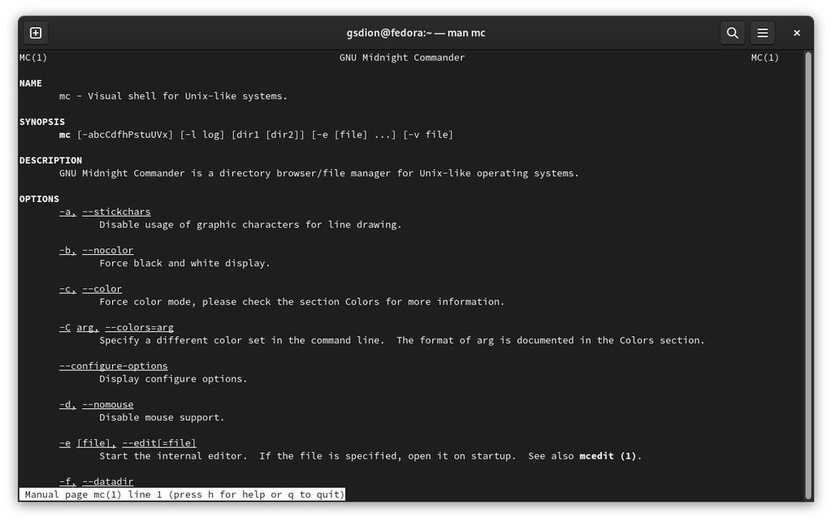

Команда man mc

## Выполнение лабораторной работы

2. Запустим из командной строки mc, изучим его структуру и меню. (рис. [-@fig:002])

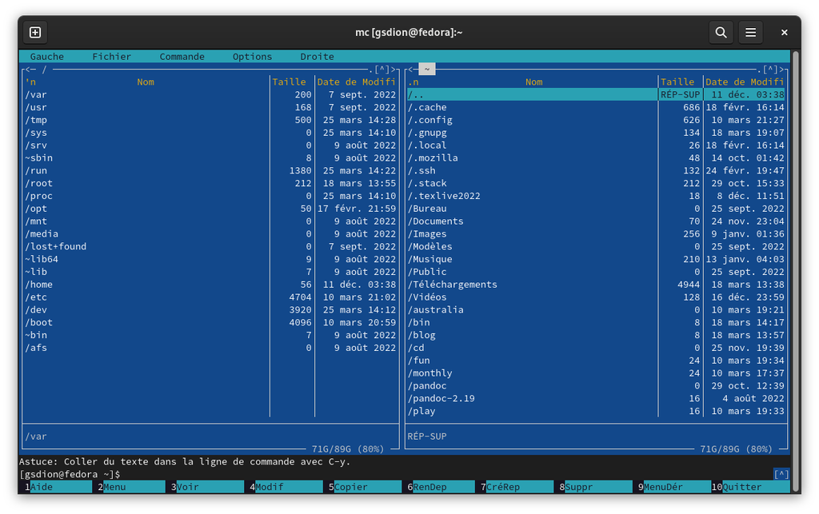

mc

## Выполнение лабораторной работы

3. Выполним несколько операций в mc, используя управляющие клавиши (операции с панелями; выделение/отмена выделения файлов, копирование/перемещение файлов, получение информации о размере и правах доступа на файлы и/или каталоги и т.п.) (рис. [-@fig:003])

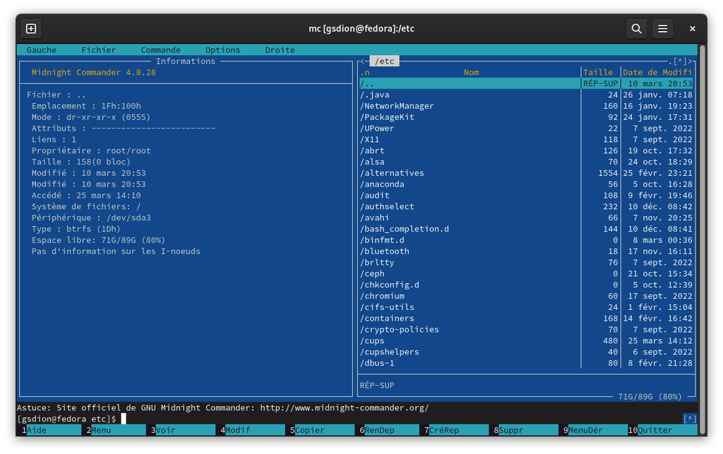

Информации о размере и правах доступа

## Выполнение лабораторной работы

4. Выполним основные команды меню левой (или правой) панели. Оцениv степень подробности вывода информации о файлах. (рис. [-@fig:004])

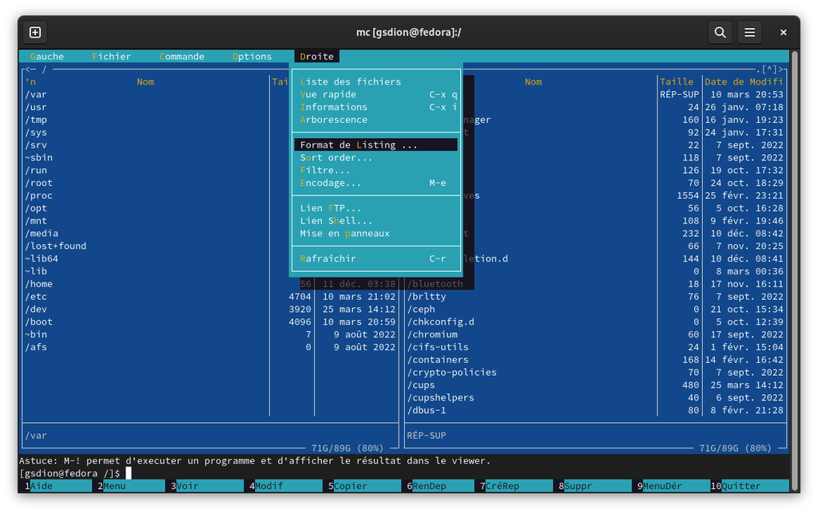

Команды правой панели

## Выполнение лабораторной работы

5. Используя возможности подменю Файл , выполним: – просмотр содержимого текстового файла; – редактирование содержимого текстового файла (без сохранения результатов редактирования); – создание каталога; – копирование файлов в созданный каталог. (рис. [-@fig:005;-@fig:006;-@fig:007])

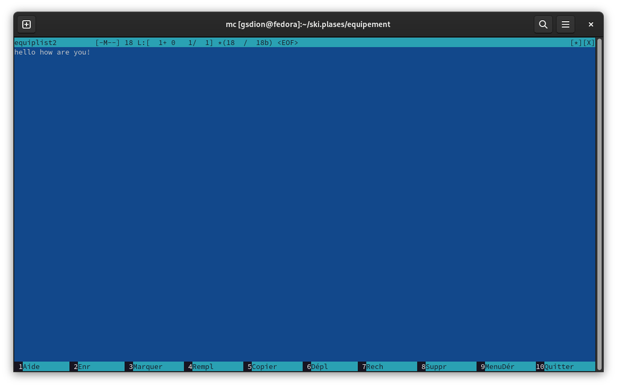

Просмотр содержимого файла

## Выполнение лабораторной работы

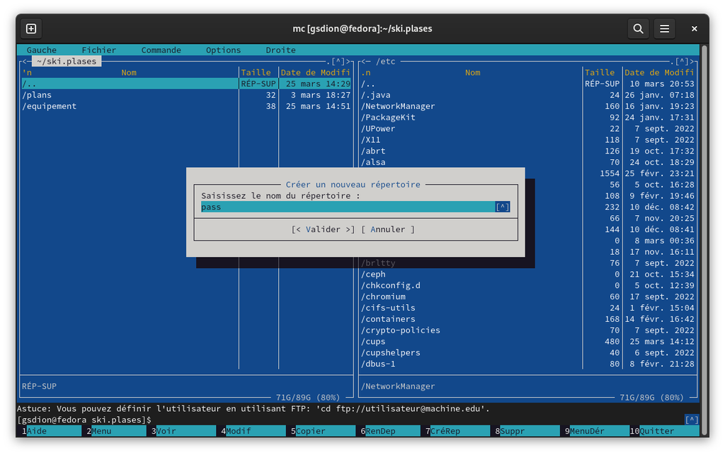

Создание каталога

## Выполнение лабораторной работы

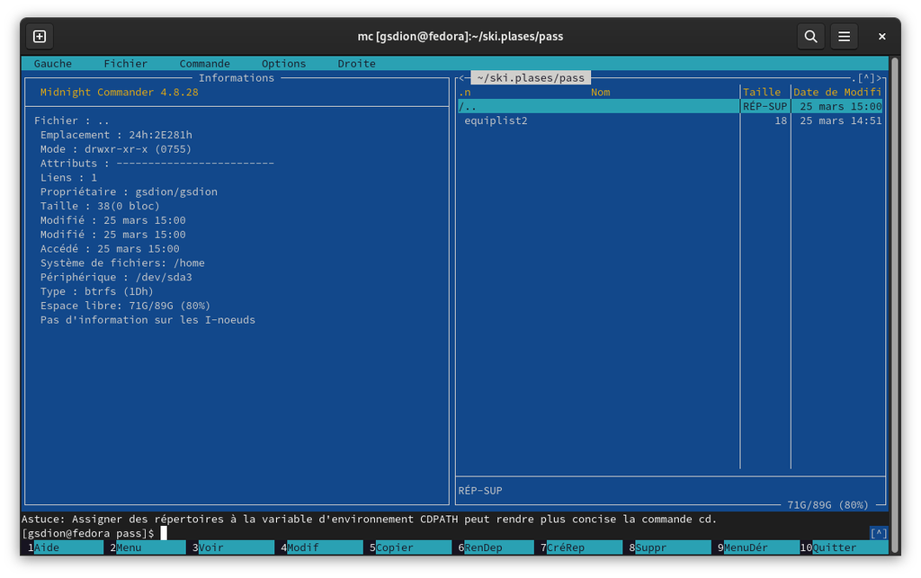

Копирование файлов в созданный каталог

## Выполнение лабораторной работы

6. С помощью соответствующих средств подменю Команда осуществим:
- поиск в файловой системе файла с заданными условиями (например, файла с расширением .c или .cpp, содержащего строку main);
- выбор и повторение одной из предыдущих команд;
- переход в домашний каталог;
- анализ файла меню и файла расширений. (рис. [-@fig:008;-@fig:009;-@fig:010;-@fig:011])

## Выполнение лабораторной работы

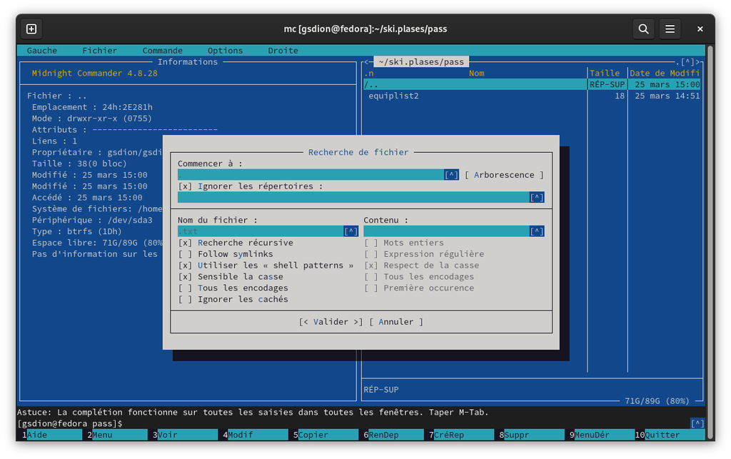

Поиск файла с расширением .txt

## Выполнение лабораторной работы

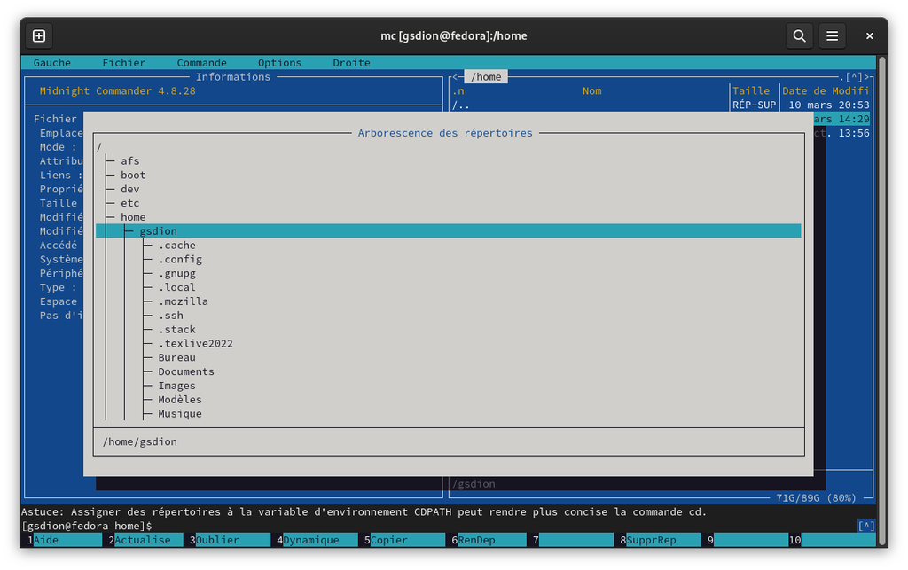

Переход в домашний каталог

## Выполнение лабораторной работы

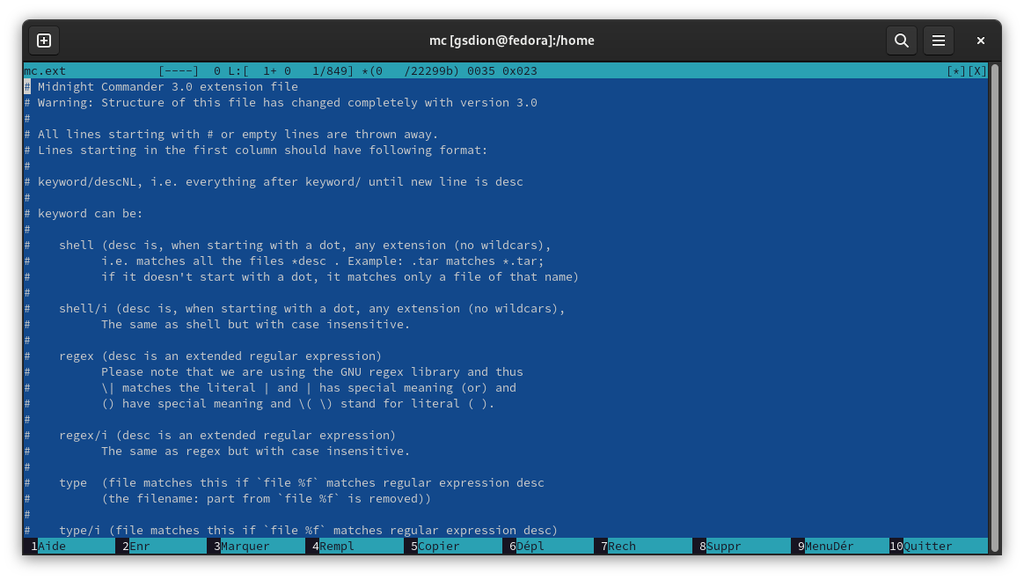

## Выполнение лабораторной работы

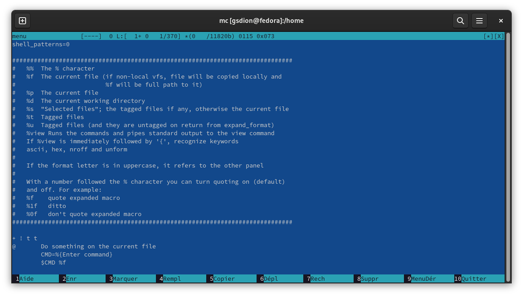

## Выполнение лабораторной работы

7. Вызовим подменю Настройки. Освоим операции, определяющие структуру экрана mc (Full screen, Double Width, Show Hidden Files и т.д.) (рис. [-@fig:012;-@fig:013;-@fig:014])

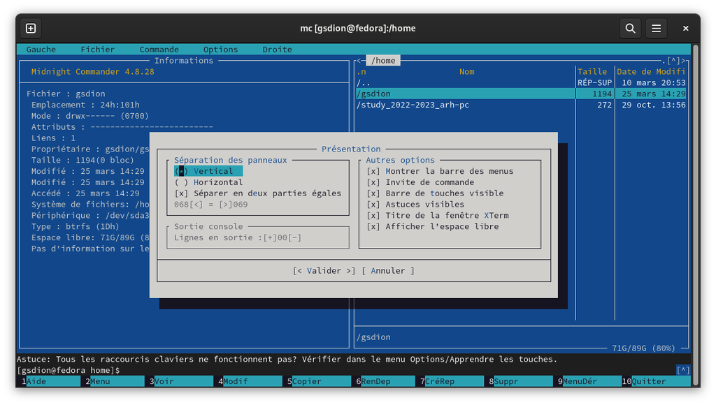

Окно “внешний вид”

## Выполнение лабораторной работы

[figure not shown]

## Выполнение лабораторной работы

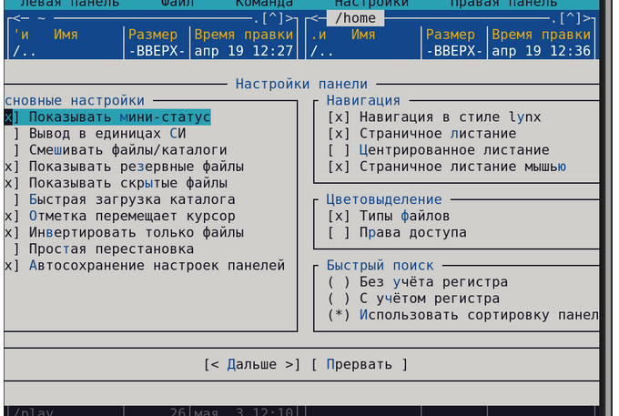

## Выполнение лабораторной работы

Задание по встроенному редактору mc: 1. Создадим текстовой файл text.txt. 2. Откроем этот файл с помощью встроенного в mc редактора. 3. Вставим в открытый файл небольшой фрагмент текста, скопированный из любого другого файла или Интернета. (рис. [-@fig:015])

[figure not shown]

## Выполнение лабораторной работы

4. Проделаем с текстом следующие манипуляции, используя горячие клавиши:
- Удалим строку текста.
- Выделим фрагмент текста и скопируем его на новую строку.
- Выделим фрагмент текста и перенесем его на новую строку.
- Сохраним файл.
- Отменим последнее действие.
- Перейдем в конец файла (нажав комбинацию клавиш) и напишем некоторый текст.
- Перейдем в начало файла (нажав комбинацию клавиш) и напишем некоторый текст.
- Сохраним и закроем файл. (рис. [-@fig:016])

## Выполнение лабораторной работы

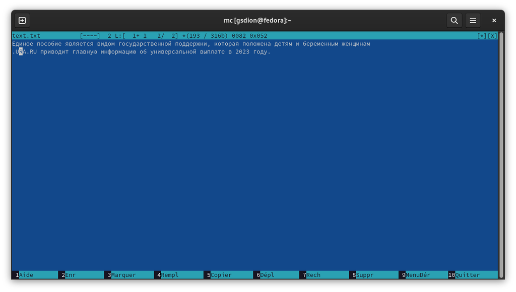

Сохранение изменений в файле text.txt

## Выполнение лабораторной работы

5. Откроем файл с исходным текстом на некотором языке программирования (например C или Java) (рис. [-@fig:017])

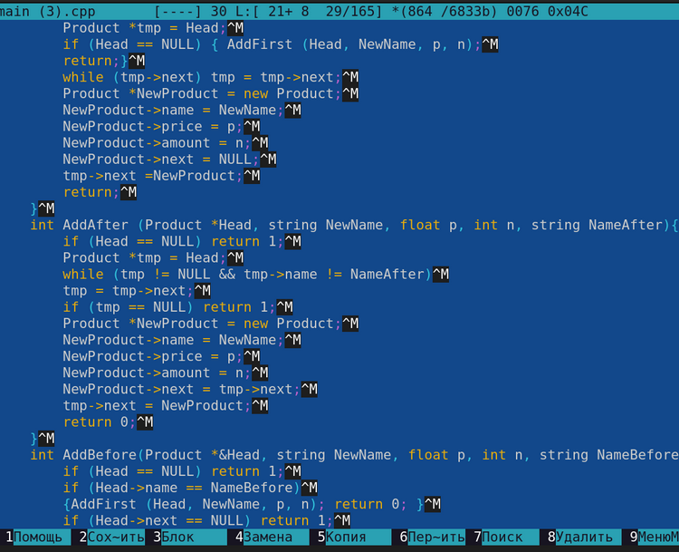

Файл на cpp

## Выполнение лабораторной работы

6. Используя меню редактора выключим подсветку синтаксиса. (рис. [-@fig:018])

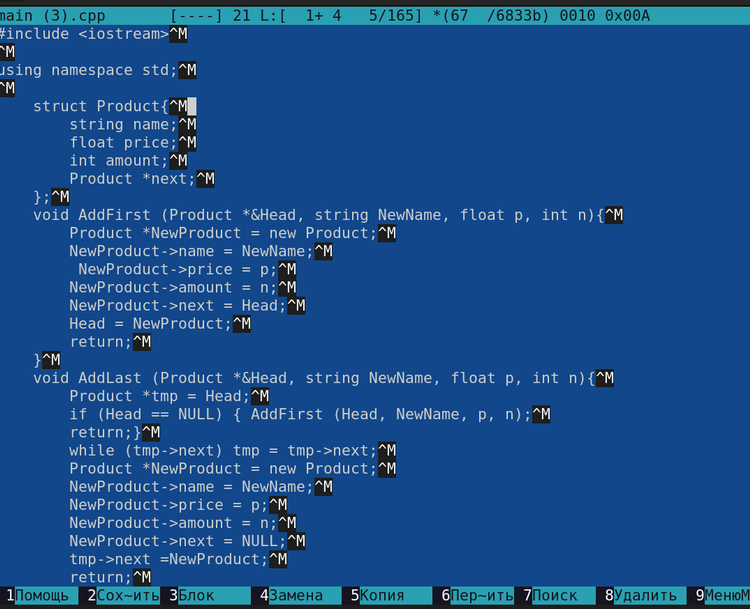

Текст программы без подстветки

## Выводы

В процессе выполнения лабораторной работы я освоила работу с командной оболочкой mc. Приобрела практические навыки работы по просмотру каталогов и файлов и по манипуляции с ними.

## Список литературы

1. Terminal Fedora [Электронный ресурс].

Спасибо за внимание!